# Distance Sampling Models

Smithsonian’s National Zoo & Conservation Biology Institute

20 September 2024

### Learning Objectives

- Become familiar with distance data importing
- Practice data exploration and cleaning
- Practice setting up analyses and running different models
- Use model outputs to identify optimal model selection and final density estimates
- Increase familiarity with the various model outputs

## Background on Distance Sampling

Distance sampling models allow researchers to estimate population size or density, typically from line or point transect surveys. Data collection for distance sampling models involves recording the distance from each sighting to the transect line/point. By explictly modeling the decreasing frequency of sightings further from the transect line/point, distance sampling models can generate density estimates that account for the proportion of the study population that went undetected during surveys. Several key assumptions of this modeling approach are that:

1. Objects on or near transects are detected with certainty (detection prob. = 1)
2. Objects are randomly distributed relative to the transect location
3. Objects should be measured from their initial location (i.e., before moving)
4. Measurements should be fairly exact (not systematically high/low)
5. Sufficient sightings exist to fit a detection function
6. Sightings should be independent of one another

## Data Preparation

We will work through a demonstration distance sampling analysis using data from Enonkishu Conservancy in Kenya. Data were collected during 5 driving transects that varied in length from approximately 3 - 12 km. Animals were recorded as groups/clusters, with perpendicular distance recorded to the center of the group. Thanks to Albert Cheruiyot and Lawrence Mbelati for allowing us to practice with this dataset!

We will start by opening a new **R** script:

1. From the “File” menu, select “New File”
2. Click “R Script” from the list of options
3. Save the R script in your working directory in the `Scripts` folder. Name this file `IntroToDistanceSampling.R`
4. Make a comment at the top of your script with your name, the date, and the purpose of the script.

```r
# ******************************************************************
# ******************************************************************

# Project: Introduction to Regression in R
# Description: A practice script which an example regression analysis
# Author: <Your Name>
# Date Initialized: <dd month yyyy>

# ******************************************************************
# ******************************************************************
```

Next, we will clear our environment and load some required packages

```r
# Clean your workspace/remove all objects
rm(list=ls())

#install.packages("unmarked", "msm")
library(tidyverse)   # For data manipulation
library(unmarked)    # For distance sampling models
library(msm)         # For confidence intervals
```

### Data Cleaning

```r
# Read in dataset
dat <- read.csv("Data/TransectData_Enonkishu.csv")

# Look at the data
View(dat)
```

There are a few things we might notice about this dataset that we need to address. First, there are two columns for ‘Species’ that we’ll need to combine into one. We’ll do this by using the **mutate** function to paste together entries from the two Species columns. Also, the start/end points of transects do not have species observations - in these cases the Species and Perpendicular Distance (PD) fields both have missing values. Finally, one transect has a “Transect_name” of “Test” and seems to have many duplicate group size measurements. We will drop this transect.

```r
# Load data
dat <- read.csv("Data/TransectData_Enonkishu.csv")

# Create a combined species field
dists <- dat %>% mutate(SpeciesBoth = paste0(Species, Species.1)) %>%
  filter(SpeciesBoth != "") %>%     # Remove records with no species info
  filter(Transect_name != "Test")   # Remove transect "Test" from the dataset
dists$Transect_name <- as.factor(dists$Transect_name)  # Convert to factor

# View the cleaned up dataset
head(dists)
```

```
##        Date     Time    Cloud          Wind Temperature Transect_name  Latitude
## 1 5/20/2024 07:34:38 Overcast Slight breeze Temperature            T4 -1.072567
## 2 5/20/2024 07:39:36 Overcast Slight breeze Temperature            T4 -1.070970
## 3 5/20/2024 07:42:25 Overcast Slight breeze Temperature            T4 -1.070214
## 4 5/20/2024 08:02:12 Overcast Slight breeze Temperature            T5 -1.061515
## 5 5/20/2024 08:02:49 Overcast Slight breeze Temperature            T5 -1.061559
## 6 5/20/2024 08:03:27 Overcast Slight breeze Temperature            T5 -1.061548
##   Longitude Altitude  PD Angle    Species         Species.1 Male Female Young
## 1  35.25649 1717.146  66    90            Thomson's Gazelle    1     NA    NA
## 2  35.26379 1727.244 171    90     Impala                      1     NA    NA
## 3  35.26554 1719.816 229    90    Giraffe                      1     NA    NA
## 4  35.26136 1724.247 243    90      Zebra                     NA     NA    NA
## 5  35.26132 1719.527 243    90    Warthog                      1     NA    NA
## 6  35.26133 1720.747 243    90 Wildebeest                      1     NA    NA
##   Group_size Transect_distance   Habitat Vigilant Passing.through
## 1          1                NA Grassland
## 2         19                NA Grassland
## 3          1                NA Grassland     True
## 4          5                NA Grassland
## 5          1                NA Grassland
## 6          1                NA Grassland
##         SpeciesBoth
## 1 Thomson's Gazelle
## 2            Impala
## 3           Giraffe
## 4             Zebra
## 5           Warthog
## 6        Wildebeest
```

Now let’s take a look at a histogram showing all perpendicular distances from our set of transects.

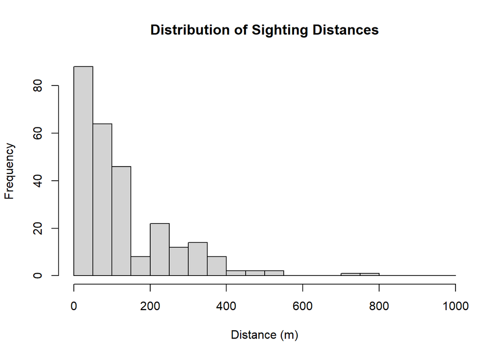

```r
hist(dists$PD, breaks = seq(0,1000,50), xlab="Distance (m)", main="Distribution of Sighting Distances")
```

We have a few outlier observations at distances beyond 500m that are not really part of the distribution. Let’s impose a cutoff distance of 500m by dropping any observations with distances > 500m. We also see that the distance curve does not look very smooth, so we will plan to combine our distances into 100m intervals for analysis. Finally, we’ll use the **summarise** function to get a count of sightings broken down by both species and transect.

```r
# Truncate to 500m
dists <- dists %>% filter(PD <= 500)# %>% filter(Transect_name != "T3") %>% droplevels()

# See how many observations we have of each species and from each transect
dists %>% summarise(count = n(), .by=SpeciesBoth) %>% arrange(desc(count))
```

```
##            SpeciesBoth count
## 1               Impala    59
## 2              Warthog    54
## 3           Wildebeest    33
## 4    Thomson's Gazelle    32
## 5                Zebra    31
## 6              Giraffe    15
## 7  Black-backed Jackal     6
## 8                Eland     5
## 9            Waterbuck     4
## 10     Grant's Gazelle     4
## 11            Elephant     3
## 12        Olive Baboon     3
## 13       Bat-eared Fox     3
## 14      Kirk's Dik-dik     2
## 15                Topi     2
## 16             Buffalo     2
## 17       Hippopotamous     2
## 18       Vervet Monkey     1
## 19                Lion     1
## 20              Cattle     1
## 21            Bushbuck     1
## 22      Dwarf Mongoose     1
## 23          Hartebeest     1
```

```r
dists %>% summarise(count = n(), .by=Transect_name)
```

```
##   Transect_name count
## 1            T4    47
## 2            T5    60
## 3            T2    95
## 4            T1    56
## 5            T3     8
```

Since it is important that we have a sufficient number of observations with distance measurements to fit our models, let’s filter our dataset to analyze just the Impala data for now. **A common rule-of-thumb is that you need a minimum of 30-40 observations of a species before you should try fitting distance sampling models**. We will then use a specialty function from the **unmarked** package to summarize our Impala sightings by Transect Name and Distance Bins.

```r
# Select data for Impala
Impala <- dists %>% filter(SpeciesBoth == "Impala")

# Summarize data by transect and distance categories (m). We could change these distances if we wanted.
yDat <- formatDistData(Impala, distCol="PD", transectNameCol="Transect_name", dist.breaks=seq(0,500,100))

yDat
```

```
##    [0,100] (100,200] (200,300] (300,400] (400,500]
## T1       7         1         0         0         0
## T2      15         3         2         0         0
## T3       0         0         2         1         0
## T4       2         4         3         1         1
## T5       7         3         5         1         1
```

Our final data preparation step is to use another specialty **unmarked** function to combine all the required data and information for fitting distance sampling models. We’ll provide our summarized distance data, specify that our survey type was “line” transects, specify the distance breaks we’re using for aggregating our observations, provide the lengths of each transect, and specify that our distance measurements are in meters.

```r
umf <- unmarkedFrameDS(
   y=as.matrix(yDat),
   siteCovs=NULL,
   survey="line",
   dist.breaks=seq(0,500,100),
   tlength=c(7500, 12000, 3000, 4500, 4500),
   unitsIn="m"
)
```

## Data Analysis

Now we have our **unmarked** dataframe ready to go and can start fitting some models! Note that when we specify a distance sampling model with **unmarked**, we have the option to list any abundance covariates after the first “~” symbol and any detection covariates after the second “~” in the model statement. Since we only have five replicate transects, we are unable to fit models with covariates, as we would generally want a minimum of 5-10 replicates for each covariate we include. There are several options for different model structures to try to fit the shape of the “detection curve” to our histogram/distance summary data. It’s generally good practice to try several different options of detection curves, since these can vary widely in terms of how well they explain our data. A poor-fitting detection curve can mean we’re pretty far off when we estimate the proportion of animals/groups that we missed during our survey. Four potential models for the detection function available in **unmarked** are the following:

- Half-normal function
- Hazard-rate function
- Exponential function
- Uniform function

Let’s fit a model to our Impala data using each of these four detection functions and compare models using AIC.

```r
m.half <- distsamp(~1 ~1, umf, keyfun="halfnorm", output="density", unitsOut="kmsq")
m.haz <- distsamp(~1 ~1, umf, keyfun="hazard", output="density", unitsOut="kmsq")
m.exp <- distsamp(~1 ~1, umf, keyfun="exp", output="density", unitsOut="kmsq")
m.uni <- distsamp(~1 ~1, umf, keyfun="uniform", output="density", unitsOut="kmsq")

fmList <- fitList(m.half=m.half, m.haz=m.haz, m.uni=m.uni, m.exp=m.exp)
modSel(fmList)
```

```
##        nPars    AIC delta   AICwt cumltvWt
## m.exp      2  96.28  0.00 6.5e-01     0.65
## m.half     2  98.68  2.40 2.0e-01     0.84
## m.haz      3  99.11  2.83 1.6e-01     1.00
## m.uni      1 136.15 39.87 1.4e-09     1.00
```

```r
# Examine model output
summary(m.exp)
```

```
##
## Call:
## distsamp(formula = ~1 ~ 1, data = umf, keyfun = "exp", output = "density",
##     unitsOut = "kmsq")
##
## Density (log-scale):
##  Estimate    SE    z  P(>|z|)
##      1.86 0.203 9.13 6.97e-20
##
## Detection (log-scale):
##  Estimate    SE    z P(>|z|)
##      5.02 0.179 28.1  2e-173
##
## AIC: 96.27599
## Number of sites: 5
## optim convergence code: 0
## optim iterations: 58
## Bootstrap iterations: 0
##
## Survey design: line-transect
## Detection function: exp
## UnitsIn: m
## UnitsOut: kmsq
```

```r
# Convert model outputs to their original scales
backTransform(m.exp, type="state")
```

```
## Backtransformed linear combination(s) of Density estimate(s)
##
##  Estimate  SE LinComb (Intercept)
##       6.4 1.3    1.86           1
##
## Transformation: exp
```

```r
backTransform(m.exp, type="det")
```

```
## Backtransformed linear combination(s) of Detection estimate(s)
##
##  Estimate   SE LinComb (Intercept)
##       152 27.2    5.02           1
##
## Transformation: exp
```

```r
# Empirical Bayes estimates of abundance at each site
ranef(m.exp)
```

```
##          Mean Mode 2.5% 97.5%
## [1,] 41.92170   41   31    54
## [2,] 62.16622   65   55    65
## [3,] 16.56975   16   10    24
## [4,] 31.35463   31   23    41
## [5,] 37.35463   37   29    47
```

## Goodness-of-Fit Testing

It is best practice to check the fit of our distance sampling models before we rely on them. Don’t worry about the details, but the block of code below will calculate three different measures of model fit - the SSE, Chi-square, and Freeman-Tukey statistics. Unlike model fitting, we want to see *non-significant* p-values here, which would indicate that our observed distance data match what would be expected based on the model.

```r
# Function returning three fit-statistics.
fitstats <- function(fm) {

  observed <- getY(fm@data)
  expected <- fitted(fm)
  resids <- residuals(fm)

  sse <- sum(resids^2)
  chisq <- sum((observed - expected)^2 / expected)
  freeTuke <- sum((sqrt(observed) - sqrt(expected))^2)

  out <- c(SSE=sse, Chisq=chisq, freemanTukey=freeTuke)

  return(out)
}

(pb <- parboot(m.exp, fitstats, nsim=100))
```

```
##
## Call: parboot(object = m.exp, statistic = fitstats, nsim = 100)
##
## Parametric Bootstrap Statistics:
##                t0 mean(t0 - t_B) StdDev(t0 - t_B) Pr(t_B > t0)
## SSE          86.3          37.00            23.53       0.0594
## Chisq        43.0          20.87             6.62       0.0000
## freemanTukey 15.8           7.47             2.04       0.0000
##
## t_B quantiles:
##                0% 2.5%  25%  50%  75% 97.5% 100%
## SSE          10.8 18.9 31.4 44.6 60.8   109  152
## Chisq         9.4 12.4 17.4 21.3 25.7    39   41
## freemanTukey  4.2  4.9  6.7  7.8  9.5    13   14
##
## t0 = Original statistic computed from data
## t_B = Vector of bootstrap samples
```

Unfortunately, our model more or less fails on all three measures! Looking back at our distance summary data (yDat), it looks like we have several transects with more observations away from the transect line than we would expect. Possibly, impala are avoiding the road or moving away from the transect line and vehicle before they are counted. Sometimes we can deal with lack-of-fit problems by smoothing our distance data into fewer bins, but we have already merged down to 5 distance categories. Another option is to fit a distance sampling model with a different “error distribution”. Rather than the classic *Poisson* distribution to describe variability in density, we could instead opt to try a different model which assumes a *Negative Binomial* distribution. The negative binomial model is better able to account for “overdispersion” and may provide a better fit to our data.

### Dealing with Overdispersion

To fit a negative binomial distance sampling model, we will need to make a new unmarked dataframe using a function specific for this type of model. We can then fit a new model with the **gdistsamp** function. This model has an added “~1” at the beginning, which allows us to model temporary emigration of animals if we have multiple surveys per transect. Since we only ran a single survey per transect, we just need to add “numPrimary=1” to our new unmarked dataframe object and select the “mixture=”NB”” option. Once we’ve fit this model, we can perform a new goodness-of-fit test.

```r
# Create updated unmarked dataframe
umf <- unmarkedFrameGDS(
  y=as.matrix(yDat),
  siteCovs=NULL,
  survey="line",
  dist.breaks=seq(0,500,100),
  tlength=c(7500, 12000, 3000, 4500, 4500),
  unitsIn="m",
  numPrimary=1  # This is the only argument we need to add
)

# Fit the NB model
m.exp.NB <- gdistsamp(~1, ~1, ~1, umf, keyfun="exp", output="density", unitsOut="kmsq", mixture="NB")

# Check model fit
(pb <- parboot(m.exp.NB, fitstats, nsim=100))
```

```
##
## Call: parboot(object = m.exp.NB, statistic = fitstats, nsim = 100)
##
## Parametric Bootstrap Statistics:
##                 t0 mean(t0 - t_B) StdDev(t0 - t_B) Pr(t_B > t0)
## SSE          336.0       -10.5944           163.96        0.465
## Chisq        502.7       -61.6332           188.60        0.594
## freemanTukey  28.4         0.0714             6.04        0.446
##
## t_B quantiles:
##               0% 2.5% 25% 50% 75% 97.5% 100%
## SSE           82  122 219 332 425   776  966
## Chisq        289  319 435 537 638  1103 1173
## freemanTukey  14   18  24  28  32    41   43
##
## t0 = Original statistic computed from data
## t_B = Vector of bootstrap samples
```

Now our model fits! Let’s look at the model output, the transect level abundance predictions, and our overall (back-transformed) density estimate.

```r
# Review model output
summary(m.exp.NB)
```

```
##
## Call:
## gdistsamp(lambdaformula = ~1, phiformula = ~1, pformula = ~1,
##     data = umf, keyfun = "exp", output = "density", unitsOut = "kmsq",
##     mixture = "NB")
##
## Abundance (log-scale):
##  Estimate    SE    z  P(>|z|)
##       1.9 0.266 7.16 8.16e-13
##
## Detection (log-scale):
##  Estimate    SE    z   P(>|z|)
##      5.02 0.179 28.1 4.04e-174
##
## Dispersion (log-scale):
##  Estimate  SE    z P(>|z|)
##         2 1.1 1.83  0.0672
##
## AIC: -25.0044
## Number of sites: 5
## optim convergence code: 0
## optim iterations: 26
## Bootstrap iterations: 0
```

```r
# Empirical Bayes estimates of abundance at each site
re <- ranef(m.exp.NB)

# Back-transform density and detection to original scale
Densities <- backTransform(m.exp.NB, type="lambda")  # "state" needs to change to "lambda" here
Detection <- backTransform(m.exp.NB, type="det")
```

### Testing for Group-size Bias

So far, we have been estimating the total number of groups, or clusters, of impala. If we want to come up with a density in terms of number of individuals, we can now multiply our density estimate by our mean group size. However, it is best practice to first make a plot of the size of the groups vs. distance of observations in a basic scatterplot and fit a linear model. Sometimes farther away groups are more likely to be under-counted, so our final point of due diligence is to make sure we don’t see a relationship between group size and distance from the transect line.

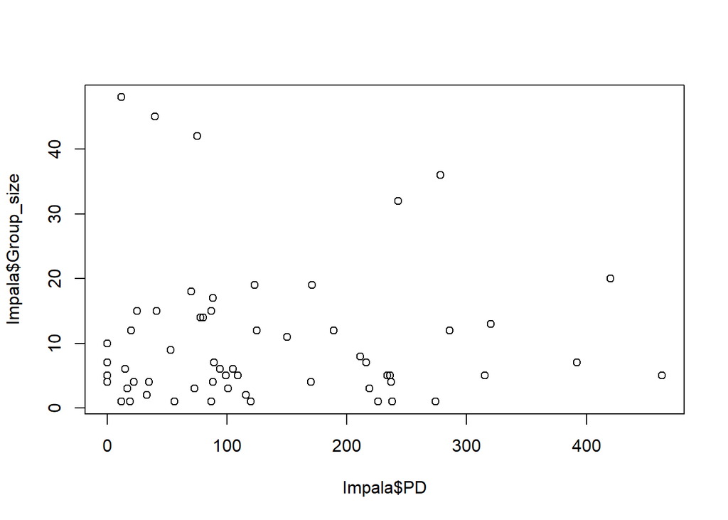

```r
#Regress cluster size on distance
plot(Impala$Group_size ~ Impala$PD)
```

```r
(cluster.det <- lm(Impala$Group_size ~ Impala$PD))
```

```
##
## Call:
## lm(formula = Impala$Group_size ~ Impala$PD)
##
## Coefficients:
## (Intercept)    Impala$PD
##   10.457372    -0.001298
```

## Final Calculations

It looks like we do not have a significant effect of distance on group size, so we’re good to move forward with our calculations. We can take our density estimate from the model and multiply by our mean group size: 6.7 x 10.3 = 69.0. We can also calculate that using our existing R objects: `Densities@estimate * mean(Impala$Group_size)`

This ‘best guess’ at the total number of impala across our transects may be good enough for some people. If we want to put confidence intervals around this abundance estimate, we will need to use the “Delta Method” as below. Don’t worry too much about the details! When we’re done, we’ll have our estimated impala abundance and 95% confidence intervals. These intervals are not very precise (we are only working with 5 transects after all), but would improve with further surveys or the introduction of covariates into the model that explain more of the variability in impala densities.

```r
# Delta method
cluster.det <- lm(Impala$Group_size ~ 1)
N1 <- cluster.det$coefficients[1]  # Mean group-size estimate from regression model
N2 <- Densities@estimate           # Estimated density of groups from distance sampling model
S1 <- vcov(cluster.det)            # Variance for group size
S2 <- vcov(Densities)              # Variance for density of groups

ind.density.se <- deltamethod(~ x1*x2, c(N1, N2), matrix(c(S1,0,0,S2),2,2))

lcl.density = max(0,(N1*N2 - 1.96 * ind.density.se))  # lower confidence limit is bounded at zero
ucl.density = N1*N2 + 1.96 * ind.density.se

CI.density = c(lcl.density, ucl.density)
CI.density
```

```
##             (Intercept)
##    28.53879   109.37496
```

## Exercise

Now that you’ve had some practice with distance sampling models, let’s try to apply what you’ve learned!

Please create a script named `Exercise_Distance.R`. Format the script like we have instructed you to do with your `Name`, `Date`, and `Description`. Fully comment your code to answer the questions below.

1. What is the total number of impala observed across all 5 transects? How does this raw count compare to our model-based estimate and confidence intervals?
2. Select another species from the Enonkishu dataset (preferably an abundant one) and come up with your best density estimate for this species.
3. Go to this link: https://ramirodcrego.shinyapps.io/DistSamplingDemo/ Try changing the values for ‘True Population Size’, ‘Number of Transects’, and ‘Number of Bins’. How do these changes affect model estimates? Can you figure out what happens when you change ‘Sigma’?

Challenge Question: 4) The code below loads data from the golf tee exercise for 7 groups. Fit a distance sampling model to this dataset and estimate the density of golf tees per square meter. The transects were 40m long and we counted out to 15m on each side of the line. You can either treat all golf tees as a single species or analyze data for just one color. The true density was 0.236 $tees/meter^2$ or 0.0295 $tees/meter^2$ if you consider just one color.

```r
# Directory where files are found
my.dir <- "Data/GolfTees/"

# List all files in a directory
file.names <-list.files(my.dir,
                        pattern=".csv",
                        ignore.case=TRUE,
                        full.names=TRUE)
# Print names
file.names
```

```
## [1] "Data/GolfTees/Group1.csv" "Data/GolfTees/Group2.csv"
## [3] "Data/GolfTees/Group3.csv" "Data/GolfTees/Group4.csv"
## [5] "Data/GolfTees/Group5.csv" "Data/GolfTees/Group6.csv"
## [7] "Data/GolfTees/Group7.csv"
```

```r
# Create blank frame to hold everything
DistData <- NULL

for (i in 1:length(unique(file.names))){
  temp <- read.csv(file.names[i], header=TRUE)
  DistData <- rbind(DistData,temp)
}

# Look at Data
head(DistData)
```

```
##   Color Distance    Group
## 1  Pink        0 Koileken
## 2  Blue        4 Koileken
## 3 White        0 Koileken
## 4  Blue        2 Koileken
## 5 White        1 Koileken
## 6 Brown        0 Koileken
```

```r
# Summarize
dim(DistData)
```

```
## [1] 545   3
```

```r
unique(DistData$Group)
```

```
## [1] "Koileken"       "KarimiSaidimu"  "EugeneGertrude" "Gideon"
## [5] "KasaineCasper"  "LokitelaGitau"  "Sam"
```